# Cyclistic Bike Share Case Study

Arjit Bhardwaj

2023-06-10

### **Introduction**

This is the capstone project as part of my Google Data Analytics Professional Certificate course. For the analysis, I will be using R programming language and RStudio IDE.

#### **Modus Operandi**

- Ask
- Prepare
- Process
- Analyse
- Share
- Act

### **Scenario**

You are a junior data analyst working in the marketing analyst team at Cyclistic, a bike-share company in Chicago. The director of marketing believes the company’s future success depends on maximizing the number of annual memberships. Therefore, your team wants to understand how casual riders and annual members use Cyclistic bikes differently. From these insights, your team will design a new marketing strategy to convert casual riders into annual members. But first, Cyclistic executives must approve your recommendations, so they must be backed up with compelling data insights and professional data visualizations.

### **Problem Statement**

- How do annual members and casual riders use Cyclistic bikes differently?
- Why would casual riders buy Cyclistic annual memberships?
- How can Cyclistic use digital media to influence casual riders to become members?

The director of marketing and your manager Lily Moreno has assigned you the first question to answer: How do annual members and casual riders use Cyclistic bikes differently?

### **Ask**

#### **Key tasks**

- Identify the business task
  - The main objective is to build the best marketing strategies to turn casual bike riders into annual members by analyzing how the ‘Casual’ and ‘Annual’ customers use Cyclistic bike share differently.
- Consider key stakeholders
  - Cyclistic executive team
  - Director of Marketing
  - Marketing Analytics team

#### **Deliverable**

- A clear statement of the business task
  - Find the difference between casual and member riders.

### **Prepare**

I will be using Cyclistic’s historical trip data to analyse and identify trends. The data has been made available by **Motivate International Inc.**

#### **Key Tasks**

- Download data and store it appropriately.
  - Data has been downloaded from [divvy-tripdata](https://divvy-tripdata.s3.amazonaws.com/index.html) and copies have been stored securely on my computer.
- Identify how it’s organised.
  - All trip data is in comma-delimited (.CSV) format. Column names - “ride_id”, “rideable_type”, “started_at”, “ended_at”, “start_station_name”, “start_station_id”, “end_station_name”,“end_station_id”, “start_lat”, “start_lng”, “end_lat”, “end_lng”, “member_casual” (Total 13 columns).
- Sort and filter the data.
  - For this analysis I’m going to use past 12 months data starting form May 2022 to April 2023.
- Determine the credibility of the data.
  - For the purpose of this case study, the datasets are appropriate and it will enable me to answer the business questions. But due to privacy policy, I cannot use rider’s personally identification information, and this will prevent me from determining if a single rider taken several rides. All ride_id are unique in this datasets.

#### **Deliverable**

- A description of all data sources used.
  - Main source data provided by Cyclistic Company.

##### **Importing the packages to be used**

```r
library(readr)
library(dplyr)
library(lubridate)
library(geosphere)
library(ggplot2)
library(ggmap)
```

##### **Import data in R Studio**

```r
df1 <- read.csv('/home/arjit/Projects/Case Study Cyclistic/Data/202205-divvy-tripdata.csv')
df2 <- read.csv('/home/arjit/Projects/Case Study Cyclistic/Data/202206-divvy-tripdata.csv')
df3 <- read.csv('/home/arjit/Projects/Case Study Cyclistic/Data/202207-divvy-tripdata.csv')
df4 <- read.csv('/home/arjit/Projects/Case Study Cyclistic/Data/202208-divvy-tripdata.csv')
df5 <- read.csv('/home/arjit/Projects/Case Study Cyclistic/Data/202209-divvy-tripdata.csv')
df6 <- read.csv('/home/arjit/Projects/Case Study Cyclistic/Data/202210-divvy-tripdata.csv')
df7 <- read.csv('/home/arjit/Projects/Case Study Cyclistic/Data/202211-divvy-tripdata.csv')
df8 <- read.csv('/home/arjit/Projects/Case Study Cyclistic/Data/202212-divvy-tripdata.csv')
df9 <- read.csv('/home/arjit/Projects/Case Study Cyclistic/Data/202301-divvy-tripdata.csv')
df10 <- read.csv('/home/arjit/Projects/Case Study Cyclistic/Data/202302-divvy-tripdata.csv')
df11 <- read.csv('/home/arjit/Projects/Case Study Cyclistic/Data/202303-divvy-tripdata.csv')
df12 <- read.csv('/home/arjit/Projects/Case Study Cyclistic/Data/202304-divvy-tripdata.csv')
```

##### **Checking the consistency of data**

```r
colnames(df1)
```

```
##  [1] "ride_id"            "rideable_type"      "started_at"
##  [4] "ended_at"           "start_station_name" "start_station_id"
##  [7] "end_station_name"   "end_station_id"     "start_lat"
## [10] "start_lng"          "end_lat"            "end_lng"
## [13] "member_casual"
```

```r
colnames(df2)
```

```
##  [1] "ride_id"            "rideable_type"      "started_at"
##  [4] "ended_at"           "start_station_name" "start_station_id"
##  [7] "end_station_name"   "end_station_id"     "start_lat"
## [10] "start_lng"          "end_lat"            "end_lng"
## [13] "member_casual"
```

```r
colnames(df3)
```

```
##  [1] "ride_id"            "rideable_type"      "started_at"
##  [4] "ended_at"           "start_station_name" "start_station_id"
##  [7] "end_station_name"   "end_station_id"     "start_lat"
## [10] "start_lng"          "end_lat"            "end_lng"
## [13] "member_casual"
```

```r
colnames(df4)
```

```
##  [1] "ride_id"            "rideable_type"      "started_at"
##  [4] "ended_at"           "start_station_name" "start_station_id"
##  [7] "end_station_name"   "end_station_id"     "start_lat"
## [10] "start_lng"          "end_lat"            "end_lng"
## [13] "member_casual"
```

```r
colnames(df5)
```

```
##  [1] "ride_id"            "rideable_type"      "started_at"
##  [4] "ended_at"           "start_station_name" "start_station_id"
##  [7] "end_station_name"   "end_station_id"     "start_lat"
## [10] "start_lng"          "end_lat"            "end_lng"
## [13] "member_casual"
```

```r
colnames(df6)
```

```
##  [1] "ride_id"            "rideable_type"      "started_at"
##  [4] "ended_at"           "start_station_name" "start_station_id"
##  [7] "end_station_name"   "end_station_id"     "start_lat"
## [10] "start_lng"          "end_lat"            "end_lng"
## [13] "member_casual"
```

```r
colnames(df7)
```

```
##  [1] "ride_id"            "rideable_type"      "started_at"
##  [4] "ended_at"           "start_station_name" "start_station_id"
##  [7] "end_station_name"   "end_station_id"     "start_lat"
## [10] "start_lng"          "end_lat"            "end_lng"
## [13] "member_casual"
```

```r
colnames(df8)
```

```
##  [1] "ride_id"            "rideable_type"      "started_at"
##  [4] "ended_at"           "start_station_name" "start_station_id"
##  [7] "end_station_name"   "end_station_id"     "start_lat"
## [10] "start_lng"          "end_lat"            "end_lng"
## [13] "member_casual"
```

```r
colnames(df9)
```

```
##  [1] "ride_id"            "rideable_type"      "started_at"
##  [4] "ended_at"           "start_station_name" "start_station_id"
##  [7] "end_station_name"   "end_station_id"     "start_lat"
## [10] "start_lng"          "end_lat"            "end_lng"
## [13] "member_casual"
```

```r
colnames(df10)
```

```
##  [1] "ride_id"            "rideable_type"      "started_at"
##  [4] "ended_at"           "start_station_name" "start_station_id"
##  [7] "end_station_name"   "end_station_id"     "start_lat"
## [10] "start_lng"          "end_lat"            "end_lng"
## [13] "member_casual"
```

```r
colnames(df11)
```

```
##  [1] "ride_id"            "rideable_type"      "started_at"
##  [4] "ended_at"           "start_station_name" "start_station_id"
##  [7] "end_station_name"   "end_station_id"     "start_lat"
## [10] "start_lng"          "end_lat"            "end_lng"
## [13] "member_casual"
```

```r
colnames(df12)
```

```
##  [1] "ride_id"            "rideable_type"      "started_at"
##  [4] "ended_at"           "start_station_name" "start_station_id"
##  [7] "end_station_name"   "end_station_id"     "start_lat"
## [10] "start_lng"          "end_lat"            "end_lng"
## [13] "member_casual"
```

##### **Checking the structure of data**

```r
str(df1)
```

```
## 'data.frame':    634858 obs. of  13 variables:
##  $ ride_id           : chr  "EC2DE40644C6B0F4" "1C31AD03897EE385" "1542FBEC830415CF" "6FF59852924528F8" ...
##  $ rideable_type     : chr  "classic_bike" "classic_bike" "classic_bike" "classic_bike" ...
##  $ started_at        : chr  "2022-05-23 23:06:58" "2022-05-11 08:53:28" "2022-05-26 18:36:28" "2022-05-10 07:30:07" ...
##  $ ended_at          : chr  "2022-05-23 23:40:19" "2022-05-11 09:31:22" "2022-05-26 18:58:18" "2022-05-10 07:38:49" ...
##  $ start_station_name: chr  "Wabash Ave & Grand Ave" "DuSable Lake Shore Dr & Monroe St" "Clinton St & Madison St" "Clinton St & Madison St" ...
##  $ start_station_id  : chr  "TA1307000117" "13300" "TA1305000032" "TA1305000032" ...
##  $ end_station_name  : chr  "Halsted St & Roscoe St" "Field Blvd & South Water St" "Wood St & Milwaukee Ave" "Clark St & Randolph St" ...
##  $ end_station_id    : chr  "TA1309000025" "15534" "13221" "TA1305000030" ...
##  $ start_lat         : num  41.9 41.9 41.9 41.9 41.9 ...
##  $ start_lng         : num  -87.6 -87.6 -87.6 -87.6 -87.6 ...
##  $ end_lat           : num  41.9 41.9 41.9 41.9 41.9 ...
##  $ end_lng           : num  -87.6 -87.6 -87.7 -87.6 -87.7 ...
##  $ member_casual     : chr  "member" "member" "member" "member" ...
```

```r
str(df2)
```

```
## 'data.frame':    769204 obs. of  13 variables:
##  $ ride_id           : chr  "600CFD130D0FD2A4" "F5E6B5C1682C6464" "B6EB6D27BAD771D2" "C9C320375DE1D5C6" ...
##  $ rideable_type     : chr  "electric_bike" "electric_bike" "electric_bike" "electric_bike" ...
##  $ started_at        : chr  "2022-06-30 17:27:53" "2022-06-30 18:39:52" "2022-06-30 11:49:25" "2022-06-30 11:15:25" ...
##  $ ended_at          : chr  "2022-06-30 17:35:15" "2022-06-30 18:47:28" "2022-06-30 12:02:54" "2022-06-30 11:19:43" ...
##  $ start_station_name: chr  "" "" "" "" ...
##  $ start_station_id  : chr  "" "" "" "" ...
##  $ end_station_name  : chr  "" "" "" "" ...
##  $ end_station_id    : chr  "" "" "" "" ...
##  $ start_lat         : num  41.9 41.9 41.9 41.8 41.9 ...
##  $ start_lng         : num  -87.6 -87.6 -87.7 -87.7 -87.6 ...
##  $ end_lat           : num  41.9 41.9 41.9 41.8 41.9 ...
##  $ end_lng           : num  -87.6 -87.6 -87.6 -87.7 -87.6 ...
##  $ member_casual     : chr  "casual" "casual" "casual" "casual" ...
```

```r
str(df3)
```

```
## 'data.frame':    823488 obs. of  13 variables:
##  $ ride_id           : chr  "954144C2F67B1932" "292E027607D218B6" "57765852588AD6E0" "B5B6BE44314590E6" ...
##  $ rideable_type     : chr  "classic_bike" "classic_bike" "classic_bike" "classic_bike" ...
##  $ started_at        : chr  "2022-07-05 08:12:47" "2022-07-26 12:53:38" "2022-07-03 13:58:49" "2022-07-31 17:44:21" ...
##  $ ended_at          : chr  "2022-07-05 08:24:32" "2022-07-26 12:55:31" "2022-07-03 14:06:32" "2022-07-31 18:42:50" ...
##  $ start_station_name: chr  "Ashland Ave & Blackhawk St" "Buckingham Fountain (Temp)" "Buckingham Fountain (Temp)" "Buckingham Fountain (Temp)" ...
##  $ start_station_id  : chr  "13224" "15541" "15541" "15541" ...
##  $ end_station_name  : chr  "Kingsbury St & Kinzie St" "Michigan Ave & 8th St" "Michigan Ave & 8th St" "Woodlawn Ave & 55th St" ...
##  $ end_station_id    : chr  "KA1503000043" "623" "623" "TA1307000164" ...
##  $ start_lat         : num  41.9 41.9 41.9 41.9 41.9 ...
##  $ start_lng         : num  -87.7 -87.6 -87.6 -87.6 -87.6 ...
##  $ end_lat           : num  41.9 41.9 41.9 41.8 41.9 ...
##  $ end_lng           : num  -87.6 -87.6 -87.6 -87.6 -87.7 ...
##  $ member_casual     : chr  "member" "casual" "casual" "casual" ...
```

```r
str(df4)
```

```
## 'data.frame':    785932 obs. of  13 variables:
##  $ ride_id           : chr  "550CF7EFEAE0C618" "DAD198F405F9C5F5" "E6F2BC47B65CB7FD" "F597830181C2E13C" ...
##  $ rideable_type     : chr  "electric_bike" "electric_bike" "electric_bike" "electric_bike" ...
##  $ started_at        : chr  "2022-08-07 21:34:15" "2022-08-08 14:39:21" "2022-08-08 15:29:50" "2022-08-08 02:43:50" ...
##  $ ended_at          : chr  "2022-08-07 21:41:46" "2022-08-08 14:53:23" "2022-08-08 15:40:34" "2022-08-08 02:58:53" ...
##  $ start_station_name: chr  "" "" "" "" ...
##  $ start_station_id  : chr  "" "" "" "" ...
##  $ end_station_name  : chr  "" "" "" "" ...
##  $ end_station_id    : chr  "" "" "" "" ...
##  $ start_lat         : num  41.9 41.9 42 41.9 41.9 ...
##  $ start_lng         : num  -87.7 -87.6 -87.7 -87.7 -87.7 ...
##  $ end_lat           : num  41.9 41.9 42 42 41.8 ...
##  $ end_lng           : num  -87.7 -87.6 -87.7 -87.7 -87.7 ...
##  $ member_casual     : chr  "casual" "casual" "casual" "casual" ...
```

```r
str(df5)
```

```
## 'data.frame':    701339 obs. of  13 variables:
##  $ ride_id           : chr  "5156990AC19CA285" "E12D4A16BF51C274" "A02B53CD7DB72DD7" "C82E05FEE872DF11" ...
##  $ rideable_type     : chr  "electric_bike" "electric_bike" "electric_bike" "electric_bike" ...
##  $ started_at        : chr  "2022-09-01 08:36:22" "2022-09-01 17:11:29" "2022-09-01 17:15:50" "2022-09-01 09:00:28" ...
##  $ ended_at          : chr  "2022-09-01 08:39:05" "2022-09-01 17:14:45" "2022-09-01 17:16:12" "2022-09-01 09:10:32" ...
##  $ start_station_name: chr  "" "" "" "" ...
##  $ start_station_id  : chr  "" "" "" "" ...
##  $ end_station_name  : chr  "California Ave & Milwaukee Ave" "" "" "" ...
##  $ end_station_id    : chr  "13084" "" "" "" ...
##  $ start_lat         : num  41.9 41.9 41.9 41.9 41.9 ...
##  $ start_lng         : num  -87.7 -87.6 -87.6 -87.7 -87.7 ...
##  $ end_lat           : num  41.9 41.9 41.9 41.9 41.9 ...
##  $ end_lng           : num  -87.7 -87.6 -87.6 -87.7 -87.7 ...
##  $ member_casual     : chr  "casual" "casual" "casual" "casual" ...
```

```r
str(df6)
```

```
## 'data.frame':    558685 obs. of  13 variables:
##  $ ride_id           : chr  "A50255C1E17942AB" "DB692A70BD2DD4E3" "3C02727AAF60F873" "47E653FDC2D99236" ...
##  $ rideable_type     : chr  "classic_bike" "electric_bike" "electric_bike" "electric_bike" ...
##  $ started_at        : chr  "2022-10-14 17:13:30" "2022-10-01 16:29:26" "2022-10-19 18:55:40" "2022-10-31 07:52:36" ...
##  $ ended_at          : chr  "2022-10-14 17:19:39" "2022-10-01 16:49:06" "2022-10-19 19:03:30" "2022-10-31 07:58:49" ...
##  $ start_station_name: chr  "Noble St & Milwaukee Ave" "Damen Ave & Charleston St" "Hoyne Ave & Balmoral Ave" "Rush St & Cedar St" ...
##  $ start_station_id  : chr  "13290" "13288" "655" "KA1504000133" ...
##  $ end_station_name  : chr  "Larrabee St & Division St" "Damen Ave & Cullerton St" "Western Ave & Leland Ave" "Orleans St & Chestnut St (NEXT Apts)" ...
##  $ end_station_id    : chr  "KA1504000079" "13089" "TA1307000140" "620" ...
##  $ start_lat         : num  41.9 41.9 42 41.9 41.9 ...
##  $ start_lng         : num  -87.7 -87.7 -87.7 -87.6 -87.6 ...
##  $ end_lat           : num  41.9 41.9 42 41.9 41.9 ...
##  $ end_lng           : num  -87.6 -87.7 -87.7 -87.6 -87.6 ...
##  $ member_casual     : chr  "member" "casual" "member" "member" ...
```

```r
str(df7)
```

```
## 'data.frame':    337735 obs. of  13 variables:
##  $ ride_id           : chr  "BCC66FC6FAB27CC7" "772AB67E902C180F" "585EAD07FDEC0152" "91C4E7ED3C262FF9" ...
##  $ rideable_type     : chr  "electric_bike" "classic_bike" "classic_bike" "classic_bike" ...
##  $ started_at        : chr  "2022-11-10 06:21:55" "2022-11-04 07:31:55" "2022-11-21 17:20:29" "2022-11-25 17:29:34" ...
##  $ ended_at          : chr  "2022-11-10 06:31:27" "2022-11-04 07:46:25" "2022-11-21 17:34:36" "2022-11-25 17:45:15" ...
##  $ start_station_name: chr  "Canal St & Adams St" "Canal St & Adams St" "Indiana Ave & Roosevelt Rd" "Indiana Ave & Roosevelt Rd" ...
##  $ start_station_id  : chr  "13011" "13011" "SL-005" "SL-005" ...
##  $ end_station_name  : chr  "St. Clair St & Erie St" "St. Clair St & Erie St" "St. Clair St & Erie St" "St. Clair St & Erie St" ...
##  $ end_station_id    : chr  "13016" "13016" "13016" "13016" ...
##  $ start_lat         : num  41.9 41.9 41.9 41.9 41.9 ...
##  $ start_lng         : num  -87.6 -87.6 -87.6 -87.6 -87.6 ...
##  $ end_lat           : num  41.9 41.9 41.9 41.9 41.9 ...
##  $ end_lng           : num  -87.6 -87.6 -87.6 -87.6 -87.6 ...
##  $ member_casual     : chr  "member" "member" "member" "member" ...
```

```r
str(df8)
```

```
## 'data.frame':    181806 obs. of  13 variables:
##  $ ride_id           : chr  "65DBD2F447EC51C2" "0C201AA7EA0EA1AD" "E0B148CCB358A49D" "54C5775D2B7C9188" ...
##  $ rideable_type     : chr  "electric_bike" "classic_bike" "electric_bike" "classic_bike" ...
##  $ started_at        : chr  "2022-12-05 10:47:18" "2022-12-18 06:42:33" "2022-12-13 08:47:45" "2022-12-13 18:50:47" ...
##  $ ended_at          : chr  "2022-12-05 10:56:34" "2022-12-18 07:08:44" "2022-12-13 08:59:51" "2022-12-13 19:19:48" ...
##  $ start_station_name: chr  "Clifton Ave & Armitage Ave" "Broadway & Belmont Ave" "Sangamon St & Lake St" "Shields Ave & 31st St" ...
##  $ start_station_id  : chr  "TA1307000163" "13277" "TA1306000015" "KA1503000038" ...
##  $ end_station_name  : chr  "Sedgwick St & Webster Ave" "Sedgwick St & Webster Ave" "St. Clair St & Erie St" "Damen Ave & Madison St" ...
##  $ end_station_id    : chr  "13191" "13191" "13016" "13134" ...
##  $ start_lat         : num  41.9 41.9 41.9 41.8 41.9 ...
##  $ start_lng         : num  -87.7 -87.6 -87.7 -87.6 -87.7 ...
##  $ end_lat           : num  41.9 41.9 41.9 41.9 41.9 ...
##  $ end_lng           : num  -87.6 -87.6 -87.6 -87.7 -87.7 ...
##  $ member_casual     : chr  "member" "casual" "member" "member" ...
```

```r
str(df9)
```

```
## 'data.frame':    190301 obs. of  13 variables:
##  $ ride_id           : chr  "F96D5A74A3E41399" "13CB7EB698CEDB88" "BD88A2E670661CE5" "C90792D034FED968" ...
##  $ rideable_type     : chr  "electric_bike" "classic_bike" "electric_bike" "classic_bike" ...
##  $ started_at        : chr  "2023-01-21 20:05:42" "2023-01-10 15:37:36" "2023-01-02 07:51:57" "2023-01-22 10:52:58" ...
##  $ ended_at          : chr  "2023-01-21 20:16:33" "2023-01-10 15:46:05" "2023-01-02 08:05:11" "2023-01-22 11:01:44" ...
##  $ start_station_name: chr  "Lincoln Ave & Fullerton Ave" "Kimbark Ave & 53rd St" "Western Ave & Lunt Ave" "Kimbark Ave & 53rd St" ...
##  $ start_station_id  : chr  "TA1309000058" "TA1309000037" "RP-005" "TA1309000037" ...
##  $ end_station_name  : chr  "Hampden Ct & Diversey Ave" "Greenwood Ave & 47th St" "Valli Produce - Evanston Plaza" "Greenwood Ave & 47th St" ...
##  $ end_station_id    : chr  "202480.0" "TA1308000002" "599" "TA1308000002" ...
##  $ start_lat         : num  41.9 41.8 42 41.8 41.8 ...
##  $ start_lng         : num  -87.6 -87.6 -87.7 -87.6 -87.6 ...
##  $ end_lat           : num  41.9 41.8 42 41.8 41.8 ...
##  $ end_lng           : num  -87.6 -87.6 -87.7 -87.6 -87.6 ...
##  $ member_casual     : chr  "member" "member" "casual" "member" ...
```

```r
str(df10)
```

```
## 'data.frame':    190445 obs. of  13 variables:
##  $ ride_id           : chr  "CBCD0D7777F0E45F" "F3EC5FCE5FF39DE9" "E54C1F27FA9354FF" "3D561E04F739CC45" ...
##  $ rideable_type     : chr  "classic_bike" "electric_bike" "classic_bike" "electric_bike" ...
##  $ started_at        : chr  "2023-02-14 11:59:42" "2023-02-15 13:53:48" "2023-02-19 11:10:57" "2023-02-26 16:12:05" ...
##  $ ended_at          : chr  "2023-02-14 12:13:38" "2023-02-15 13:59:08" "2023-02-19 11:35:01" "2023-02-26 16:39:55" ...
##  $ start_station_name: chr  "Southport Ave & Clybourn Ave" "Clarendon Ave & Gordon Ter" "Southport Ave & Clybourn Ave" "Southport Ave & Clybourn Ave" ...
##  $ start_station_id  : chr  "TA1309000030" "13379" "TA1309000030" "TA1309000030" ...
##  $ end_station_name  : chr  "Clark St & Schiller St" "Sheridan Rd & Lawrence Ave" "Aberdeen St & Monroe St" "Franklin St & Adams St (Temp)" ...
##  $ end_station_id    : chr  "TA1309000024" "TA1309000041" "13156" "TA1309000008" ...
##  $ start_lat         : num  41.9 42 41.9 41.9 41.8 ...
##  $ start_lng         : num  -87.7 -87.6 -87.7 -87.7 -87.6 ...
##  $ end_lat           : num  41.9 42 41.9 41.9 41.8 ...
##  $ end_lng           : num  -87.6 -87.7 -87.7 -87.6 -87.6 ...
##  $ member_casual     : chr  "casual" "casual" "member" "member" ...
```

```r
str(df11)
```

```
## 'data.frame':    258678 obs. of  13 variables:
##  $ ride_id           : chr  "6842AA605EE9FBB3" "F984267A75B99A8C" "FF7CF57CFE026D02" "6B61B916032CB6D6" ...
##  $ rideable_type     : chr  "electric_bike" "electric_bike" "classic_bike" "classic_bike" ...
##  $ started_at        : chr  "2023-03-16 08:20:34" "2023-03-04 14:07:06" "2023-03-31 12:28:09" "2023-03-22 14:09:08" ...
##  $ ended_at          : chr  "2023-03-16 08:22:52" "2023-03-04 14:15:31" "2023-03-31 12:38:47" "2023-03-22 14:24:51" ...
##  $ start_station_name: chr  "Clark St & Armitage Ave" "Public Rack - Kedzie Ave & Argyle St" "Orleans St & Chestnut St (NEXT Apts)" "Desplaines St & Kinzie St" ...
##  $ start_station_id  : chr  "13146" "491" "620" "TA1306000003" ...
##  $ end_station_name  : chr  "Larrabee St & Webster Ave" "" "Clark St & Randolph St" "Sheffield Ave & Kingsbury St" ...
##  $ end_station_id    : chr  "13193" "" "TA1305000030" "13154" ...
##  $ start_lat         : num  41.9 42 41.9 41.9 41.9 ...
##  $ start_lng         : num  -87.6 -87.7 -87.6 -87.6 -87.7 ...
##  $ end_lat           : num  41.9 42 41.9 41.9 41.9 ...
##  $ end_lng           : num  -87.6 -87.7 -87.6 -87.7 -87.7 ...
##  $ member_casual     : chr  "member" "member" "member" "member" ...
```

```r
str(df12)
```

```
## 'data.frame':    426590 obs. of  13 variables:
##  $ ride_id           : chr  "8FE8F7D9C10E88C7" "34E4ED3ADF1D821B" "5296BF07A2F77CB5" "40759916B76D5D52" ...
##  $ rideable_type     : chr  "electric_bike" "electric_bike" "electric_bike" "electric_bike" ...
##  $ started_at        : chr  "2023-04-02 08:37:28" "2023-04-19 11:29:02" "2023-04-19 08:41:22" "2023-04-19 13:31:30" ...
##  $ ended_at          : chr  "2023-04-02 08:41:37" "2023-04-19 11:52:12" "2023-04-19 08:43:22" "2023-04-19 13:35:09" ...
##  $ start_station_name: chr  "" "" "" "" ...
##  $ start_station_id  : chr  "" "" "" "" ...
##  $ end_station_name  : chr  "" "" "" "" ...
##  $ end_station_id    : chr  "" "" "" "" ...
##  $ start_lat         : num  41.8 41.9 41.9 41.9 41.9 ...
##  $ start_lng         : num  -87.6 -87.7 -87.7 -87.7 -87.7 ...
##  $ end_lat           : num  41.8 41.9 41.9 41.9 41.9 ...
##  $ end_lng           : num  -87.6 -87.7 -87.7 -87.7 -87.6 ...
##  $ member_casual     : chr  "member" "member" "member" "member" ...
```

##### **Merging 12 datasets into 1 dataset**

```r
all_rides <- rbind(df1, df2, df3, df4, df5, df6, df7, df8, df9, df10, df11, df12)
```

##### **Creating a file of the merged dataset**

```r
write_csv(all_rides, '/home/arjit/Projects/Case Study Cyclistic/Data/all_rides.csv')
```

### **Process**

Cleaning and processing data for analysis

#### **Key tasks**

- Check the data for errors
- Choose your tools
- Transform the data so you can work with it effectively
- Document the cleaning process

#### **Deliverable**

- Documentation of any cleaning or manipulating the data

##### **Analyzing the the structure of attributes**

```r
sapply(all_rides, class)
```

```
##            ride_id      rideable_type         started_at           ended_at
##        "character"        "character"        "character"        "character"
## start_station_name   start_station_id   end_station_name     end_station_id
##        "character"        "character"        "character"        "character"
##          start_lat          start_lng            end_lat            end_lng
##          "numeric"          "numeric"          "numeric"          "numeric"
##      member_casual
##        "character"
```

##### **Number of columns, rows and total NA values**

```r
ncol(all_rides)
```

```
## [1] 13
```

```r
nrow(all_rides)
```

```
## [1] 5859061
```

```r
sum(is.na(all_rides))
```

```
## [1] 11946
```

##### **Removing all the empty cells**

```r
all_rides <- janitor::remove_empty(all_rides, which=c("cols"))
all_rides <- janitor::remove_empty(all_rides, which=c("rows"))
```

##### **Removing all the NA values**

```r
all_rides <- na.omit(all_rides)
sum(is.na(all_rides))
```

```
## [1] 0
```

##### **Checking the number of rows left after removing NA**

```r
nrow(all_rides)
```

```
## [1] 5853088
```

##### **Checking the dimension of the dataset**

```r
dim(all_rides)
```

```
## [1] 5853088      13
```

##### **Calculating the ride time**

```r
all_rides$minutes <- difftime(all_rides$ended_at, all_rides$started_at, units = c("min"))
all_rides$minutes <- as.numeric(as.character(all_rides$minutes))
all_rides$minutes <- round(all_rides$minutes, 1)
```

##### **Checking the datatype of “minutes” column**

```r
is.numeric(all_rides$minutes)
```

```
## [1] TRUE
```

##### **Adding date, month, day, year, day of week, hour columns**

```r
all_rides$date <- as.Date(all_rides$started_at)
all_rides$month <- format(as.Date(all_rides$date), "%m")
all_rides$day <- format(as.Date(all_rides$date), "%d")
all_rides$year <- format(as.Date(all_rides$date), "%Y")
all_rides$day_of_week <- format(as.Date(all_rides$date), "%A")
all_rides$hour <- hour(all_rides$started_at)
```

##### **Checking the modified dataset**

```r
head(all_rides)
```

```
##            ride_id rideable_type          started_at            ended_at
## 1 EC2DE40644C6B0F4  classic_bike 2022-05-23 23:06:58 2022-05-23 23:40:19
## 2 1C31AD03897EE385  classic_bike 2022-05-11 08:53:28 2022-05-11 09:31:22
## 3 1542FBEC830415CF  classic_bike 2022-05-26 18:36:28 2022-05-26 18:58:18
## 4 6FF59852924528F8  classic_bike 2022-05-10 07:30:07 2022-05-10 07:38:49
## 5 483C52CAAE12E3AC  classic_bike 2022-05-10 17:31:56 2022-05-10 17:36:57
## 6 C0A3AA5A614DCE01  classic_bike 2022-05-04 14:48:55 2022-05-04 14:56:04
##                  start_station_name start_station_id
## 1            Wabash Ave & Grand Ave     TA1307000117
## 2 DuSable Lake Shore Dr & Monroe St            13300
## 3           Clinton St & Madison St     TA1305000032
## 4           Clinton St & Madison St     TA1305000032
## 5           Clinton St & Madison St     TA1305000032
## 6           Carpenter St & Huron St            13196
##                end_station_name end_station_id start_lat start_lng  end_lat
## 1        Halsted St & Roscoe St   TA1309000025  41.89147 -87.62676 41.94367
## 2   Field Blvd & South Water St          15534  41.88096 -87.61674 41.88635
## 3       Wood St & Milwaukee Ave          13221  41.88224 -87.64107 41.90765
## 4        Clark St & Randolph St   TA1305000030  41.88224 -87.64107 41.88458
## 5           Morgan St & Lake St   TA1306000015  41.88224 -87.64107 41.88578
## 6 Sangamon St & Washington Blvd          13409  41.89456 -87.65345 41.88316
##     end_lng member_casual minutes       date month day year day_of_week hour
## 1 -87.64895        member    33.4 2022-05-23    05  23 2022      Monday   23
## 2 -87.61752        member    37.9 2022-05-11    05  11 2022   Wednesday    8
## 3 -87.67255        member    21.8 2022-05-26    05  26 2022    Thursday   18
## 4 -87.63189        member     8.7 2022-05-10    05  10 2022     Tuesday    7
## 5 -87.65102        member     5.0 2022-05-10    05  10 2022     Tuesday   17
## 6 -87.65110        member     7.2 2022-05-04    05  04 2022   Wednesday   14
```

##### **Adding the season column**

```r
all_rides <- all_rides %>% mutate(season = case_when(month == "01" ~ "Winter",
                                                     month == "02" ~ "Winter",
                                                     month == "03" ~ "Spring",
                                                     month == "04" ~ "Spring",
                                                     month == "05" ~ "Summer",
                                                     month == "06" ~ "Summer",
                                                     month == "07" ~ "Summer",
                                                     month == "08" ~ "Summer",
                                                     month == "09" ~ "Fall",
                                                     month == "10" ~ "Fall",
                                                     month == "11" ~ "Winter",
                                                     month == "12" ~ "Winter"))
```

##### **Mapping the time column to phases of a day**

```r
all_rides <- all_rides %>% mutate(time_of_day = case_when(hour == "0" ~ "Night",
                                                          hour == "1" ~ "Night",
                                                          hour == "2" ~ "Night",
                                                          hour == "3" ~ "Night",
                                                          hour == "4" ~ "Night",
                                                          hour == "5" ~ "Morning",
                                                          hour == "6" ~ "Morning",
                                                          hour == "7" ~ "Morning",
                                                          hour == "8" ~ "Morning",
                                                          hour == "9" ~ "Morning",
                                                          hour == "10" ~ "Morning",
                                                          hour == "11" ~ "Morning",
                                                          hour == "12" ~ "Afternoon",
                                                          hour == "13" ~ "Afternoon",
                                                          hour == "14" ~ "Afternoon",
                                                          hour == "15" ~ "Afternoon",
                                                          hour == "16" ~ "Afternoon",
                                                          hour == "17" ~ "Afternoon",
                                                          hour == "18" ~ "Evening",
                                                          hour == "19" ~ "Evening",
                                                          hour == "20" ~ "Evening",
                                                          hour == "21" ~ "Evening",
                                                          hour == "22" ~ "Evening",
                                                          hour == "23" ~ "Evening"))
```

##### **Mapping the months to their names**

```r
all_rides <- all_rides %>% mutate(month = case_when(month == "01" ~ "January",
                                                    month == "02" ~ "February",
                                                    month == "03" ~ "March",
                                                    month == "04" ~ "April",
                                                    month == "05" ~ "May",
                                                    month == "06" ~ "June",
                                                    month == "07" ~ "July",
                                                    month == "08" ~ "August",
                                                    month == "09" ~ "September",
                                                    month == "10" ~ "October",
                                                    month == "11" ~ "November",
                                                    month == "12" ~ "December"))
```

##### **Verifying the results**

```r
tail(all_rides)
```

```
##                  ride_id rideable_type          started_at            ended_at
## 5859056 A17D800CE963661A  classic_bike 2023-04-11 15:46:42 2023-04-11 15:50:03
## 5859057 8B441A6C436E9900  classic_bike 2023-04-29 21:20:21 2023-04-29 21:30:19
## 5859058 3980D64BE11540F1  classic_bike 2023-04-24 09:16:05 2023-04-24 09:22:27
## 5859059 3EF4B49FF7DAA02C  classic_bike 2023-04-18 07:53:51 2023-04-18 07:59:16
## 5859060 210B2ED6583DC231  classic_bike 2023-04-29 07:33:55 2023-04-29 07:38:57
## 5859061 D29CB39B9E3FC46A electric_bike 2023-04-18 08:00:32 2023-04-18 08:02:35
##                 start_station_name start_station_id          end_station_name
## 5859056     Michigan Ave & Lake St     TA1305000011    Clark St & Randolph St
## 5859057       Halsted St & 18th St            13099 Blue Island Ave & 18th St
## 5859058       Halsted St & 18th St            13099 Blue Island Ave & 18th St
## 5859059 Franklin St & Jackson Blvd     TA1305000025    Clark St & Randolph St
## 5859060     Michigan Ave & Lake St     TA1305000011    Clark St & Randolph St
## 5859061 Franklin St & Jackson Blvd     TA1305000025 Clark St & Ida B Wells Dr
##         end_station_id start_lat start_lng  end_lat   end_lng member_casual
## 5859056   TA1305000030  41.88602 -87.62440 41.88458 -87.63189        member
## 5859057          13135  41.85751 -87.64599 41.85756 -87.66154        casual
## 5859058          13135  41.85751 -87.64599 41.85756 -87.66154        casual
## 5859059   TA1305000030  41.87771 -87.63532 41.88458 -87.63189        casual
## 5859060   TA1305000030  41.88602 -87.62440 41.88458 -87.63189        casual
## 5859061   TA1305000009  41.87813 -87.63525 41.87593 -87.63058        casual
##         minutes       date month day year day_of_week hour season time_of_day
## 5859056     3.4 2023-04-11 April  11 2023     Tuesday   15 Spring   Afternoon
## 5859057    10.0 2023-04-29 April  29 2023    Saturday   21 Spring     Evening
## 5859058     6.4 2023-04-24 April  24 2023      Monday    9 Spring     Morning
## 5859059     5.4 2023-04-18 April  18 2023     Tuesday    7 Spring     Morning
## 5859060     5.0 2023-04-29 April  29 2023    Saturday    7 Spring     Morning
## 5859061     2.0 2023-04-18 April  18 2023     Tuesday    8 Spring     Morning
```

### **Analyze**

Now all the required information are in one place and ready for exploration.

#### **Key tasks**

- Aggregate your data so it’s useful and accessible.
- Organise and format your data.
- Perform calculations.
- Identify trends and relationships.

#### **Deliverable**

- A summary of analysis.

##### **Checking the unique types of ride available**

```r
unique(all_rides$rideable_type)
```

```
## [1] "classic_bike"  "docked_bike"   "electric_bike"
```

##### **Checking the unique values in member_casual**

```r
unique(all_rides$member_casual)
```

```
## [1] "member" "casual"
```

##### **Verifying if there are any NA in dataset**

```r
sum(is.na(all_rides))
```

```
## [1] 0
```

```r
#distinct(all_rides)
```

```r
dim(all_rides)
```

```
## [1] 5853088      22
```

```r
write_csv(all_rides, '/home/arjit/Projects/Case Study Cyclistic/Data/all_rides_modified.csv')
```

```r
df <- read_csv('/home/arjit/Projects/Case Study Cyclistic/Data/all_rides_modified.csv')
head(df)
```

```
## # A tibble: 6 × 22
##   ride_id          rideable_type started_at          ended_at
##   <chr>            <chr>         <dttm>              <dttm>
## 1 EC2DE40644C6B0F4 classic_bike  2022-05-23 23:06:58 2022-05-23 23:40:19
## 2 1C31AD03897EE385 classic_bike  2022-05-11 08:53:28 2022-05-11 09:31:22
## 3 1542FBEC830415CF classic_bike  2022-05-26 18:36:28 2022-05-26 18:58:18
## 4 6FF59852924528F8 classic_bike  2022-05-10 07:30:07 2022-05-10 07:38:49
## 5 483C52CAAE12E3AC classic_bike  2022-05-10 17:31:56 2022-05-10 17:36:57
## 6 C0A3AA5A614DCE01 classic_bike  2022-05-04 14:48:55 2022-05-04 14:56:04
## # ℹ 18 more variables: start_station_name <chr>, start_station_id <chr>,
## #   end_station_name <chr>, end_station_id <chr>, start_lat <dbl>,
## #   start_lng <dbl>, end_lat <dbl>, end_lng <dbl>, member_casual <chr>,
## #   minutes <dbl>, date <date>, month <chr>, day <chr>, year <dbl>,
## #   day_of_week <chr>, hour <dbl>, season <chr>, time_of_day <chr>
```

```r
dim(df)
```

```
## [1] 5853088      22
```

##### **Checking the structure of dataset**

```r
str(df)
```

```
## spc_tbl_ [5,853,088 × 22] (S3: spec_tbl_df/tbl_df/tbl/data.frame)
##  $ ride_id           : chr [1:5853088] "EC2DE40644C6B0F4" "1C31AD03897EE385" "1542FBEC830415CF" "6FF59852924528F8" ...
##  $ rideable_type     : chr [1:5853088] "classic_bike" "classic_bike" "classic_bike" "classic_bike" ...
##  $ started_at        : POSIXct[1:5853088], format: "2022-05-23 23:06:58" "2022-05-11 08:53:28" ...
##  $ ended_at          : POSIXct[1:5853088], format: "2022-05-23 23:40:19" "2022-05-11 09:31:22" ...
##  $ start_station_name: chr [1:5853088] "Wabash Ave & Grand Ave" "DuSable Lake Shore Dr & Monroe St" "Clinton St & Madison St" "Clinton St & Madison St" ...
##  $ start_station_id  : chr [1:5853088] "TA1307000117" "13300" "TA1305000032" "TA1305000032" ...
##  $ end_station_name  : chr [1:5853088] "Halsted St & Roscoe St" "Field Blvd & South Water St" "Wood St & Milwaukee Ave" "Clark St & Randolph St" ...
##  $ end_station_id    : chr [1:5853088] "TA1309000025" "15534" "13221" "TA1305000030" ...
##  $ start_lat         : num [1:5853088] 41.9 41.9 41.9 41.9 41.9 ...
##  $ start_lng         : num [1:5853088] -87.6 -87.6 -87.6 -87.6 -87.6 ...
##  $ end_lat           : num [1:5853088] 41.9 41.9 41.9 41.9 41.9 ...
##  $ end_lng           : num [1:5853088] -87.6 -87.6 -87.7 -87.6 -87.7 ...
##  $ member_casual     : chr [1:5853088] "member" "member" "member" "member" ...
##  $ minutes           : num [1:5853088] 33.4 37.9 21.8 8.7 5 7.2 8.9 12.2 16.7 1.5 ...
##  $ date              : Date[1:5853088], format: "2022-05-23" "2022-05-11" ...
##  $ month             : chr [1:5853088] "May" "May" "May" "May" ...
##  $ day               : chr [1:5853088] "23" "11" "26" "10" ...
##  $ year              : num [1:5853088] 2022 2022 2022 2022 2022 ...
##  $ day_of_week       : chr [1:5853088] "Monday" "Wednesday" "Thursday" "Tuesday" ...
##  $ hour              : num [1:5853088] 23 8 18 7 17 14 12 19 17 7 ...
##  $ season            : chr [1:5853088] "Summer" "Summer" "Summer" "Summer" ...
##  $ time_of_day       : chr [1:5853088] "Evening" "Morning" "Evening" "Morning" ...
##  - attr(*, "spec")=
##   .. cols(
##   ..   ride_id = col_character(),
##   ..   rideable_type = col_character(),
##   ..   started_at = col_datetime(format = ""),
##   ..   ended_at = col_datetime(format = ""),
##   ..   start_station_name = col_character(),
##   ..   start_station_id = col_character(),
##   ..   end_station_name = col_character(),
##   ..   end_station_id = col_character(),
##   ..   start_lat = col_double(),
##   ..   start_lng = col_double(),
##   ..   end_lat = col_double(),
##   ..   end_lng = col_double(),
##   ..   member_casual = col_character(),
##   ..   minutes = col_double(),
##   ..   date = col_date(format = ""),
##   ..   month = col_character(),
##   ..   day = col_character(),
##   ..   year = col_double(),
##   ..   day_of_week = col_character(),
##   ..   hour = col_double(),
##   ..   season = col_character(),
##   ..   time_of_day = col_character()
##   .. )
##  - attr(*, "problems")=<externalptr>
```

##### **Analyzing the summary of the dataset**

```r
summary(df)
```

```
##    ride_id          rideable_type        started_at
##  Length:5853088     Length:5853088     Min.   :2022-05-01 00:00:06
##  Class :character   Class :character   1st Qu.:2022-07-03 11:25:11
##  Mode  :character   Mode  :character   Median :2022-08-28 13:00:14
##                                        Mean   :2022-09-19 14:02:11
##                                        3rd Qu.:2022-11-08 07:01:29
##                                        Max.   :2023-04-30 23:59:05
##     ended_at                   start_station_name start_station_id
##  Min.   :2022-05-01 00:05:17   Length:5853088     Length:5853088
##  1st Qu.:2022-07-03 11:48:44   Class :character   Class :character
##  Median :2022-08-28 13:20:19   Mode  :character   Mode  :character
##  Mean   :2022-09-19 14:18:00
##  3rd Qu.:2022-11-08 07:12:01
##  Max.   :2023-05-01 08:06:56
##  end_station_name   end_station_id       start_lat       start_lng
##  Length:5853088     Length:5853088     Min.   :41.64   Min.   :-87.84
##  Class :character   Class :character   1st Qu.:41.88   1st Qu.:-87.66
##  Mode  :character   Mode  :character   Median :41.90   Median :-87.64
##                                        Mean   :41.90   Mean   :-87.65
##                                        3rd Qu.:41.93   3rd Qu.:-87.63
##                                        Max.   :42.07   Max.   :-87.52
##     end_lat         end_lng       member_casual         minutes
##  Min.   : 0.00   Min.   :-88.14   Length:5853088     Min.   :-10353.40
##  1st Qu.:41.88   1st Qu.:-87.66   Class :character   1st Qu.:     5.70
##  Median :41.90   Median :-87.64   Mode  :character   Median :    10.00
##  Mean   :41.90   Mean   :-87.65                      Mean   :    15.83
##  3rd Qu.:41.93   3rd Qu.:-87.63                      3rd Qu.:    17.90
##  Max.   :42.37   Max.   :  0.00                      Max.   : 32035.40
##       date               month               day                 year
##  Min.   :2022-05-01   Length:5853088     Length:5853088     Min.   :2022
##  1st Qu.:2022-07-03   Class :character   Class :character   1st Qu.:2022
##  Median :2022-08-28   Mode  :character   Mode  :character   Median :2022
##  Mean   :2022-09-18                                         Mean   :2022
##  3rd Qu.:2022-11-08                                         3rd Qu.:2022
##  Max.   :2023-04-30                                         Max.   :2023
##  day_of_week             hour          season          time_of_day
##  Length:5853088     Min.   : 0.00   Length:5853088     Length:5853088
##  Class :character   1st Qu.:11.00   Class :character   Class :character
##  Mode  :character   Median :15.00   Mode  :character   Mode  :character
##                     Mean   :14.21
##                     3rd Qu.:18.00
##                     Max.   :23.00
```

##### **Calculating the ride length in kilometers**

```r
df$ride_length <- distGeo(matrix(c(df$start_lng, df$start_lat), ncol = 2), matrix(c(df$end_lng, df$end_lat), ncol = 2))

df$ride_length <- df$ride_length/1000
```

##### **Removing the rows with ride length as negative or zero**

```r
df <- df[!(df$ride_length <= 0),]
```

##### **Removing the NA in the dataset**

```r
sum(is.na(df))
```

```
## [1] 3020593
```

```r
df <- na.omit(df)
```

#### **Doing descriptive analysis, studying:**

- avg_ride_length -> straight average(total ride length / total rides)
- median_length -> midpoint number of ride length
- max_ride_length -> longest ride
- min_ride_length -> shortest ride

```r
df %>% summarise(avg_ride_length = mean(ride_length), median_length = median(ride_length),
                 max_ride_length = max(ride_length), min_ride_length = min(ride_length))
```

```
## # A tibble: 1 × 4
##   avg_ride_length median_length max_ride_length min_ride_length
##             <dbl>         <dbl>           <dbl>           <dbl>
## 1            2.18          1.61           9817.       0.0000185
```

#### **Compare members and casual riders**

- Member vs casual riders difference depending on the total rides taken

```r
df %>%
    group_by(member_casual) %>%
    summarise(ride_count = length(ride_id), ride_percentage = (length(ride_id) / nrow(df)) * 100)
```

```
## # A tibble: 2 × 3
##   member_casual ride_count ride_percentage
##   <chr>              <int>           <dbl>
## 1 casual           1668876            38.5
## 2 member           2663765            61.5
```

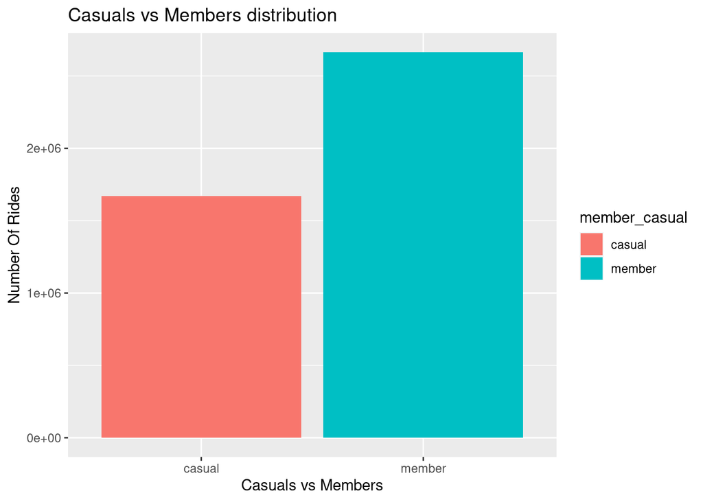

```r
ggplot(df, aes(x = member_casual, fill=member_casual)) +
    geom_bar() +
    labs(x="Casuals vs Members", y="Number Of Rides", title= "Casuals vs Members distribution")
```

#### **Comparison between Member Casual riders depending on ride length**

```r
df %>%
  group_by(member_casual) %>%
  summarise(avg_ride_length = mean(ride_length), median_length = median(ride_length),
            max_ride_length = max(ride_length), min_ride_length = min(ride_length))
```

```
## # A tibble: 2 × 5
##   member_casual avg_ride_length median_length max_ride_length min_ride_length
##   <chr>                   <dbl>         <dbl>           <dbl>           <dbl>
## 1 casual                   2.29          1.74           9817.       0.0000185
## 2 member                   2.12          1.53           9817.       0.0000202
```

#### **Fixing the names of days in a week**

```r
df$day_of_week <- ordered(df$day_of_week,
                                    levels=c("Sunday", "Monday", "Tuesday", "Wednesday", "Thursday", "Friday", "Saturday"))
df %>%
  group_by(member_casual, day_of_week) %>%
  summarise(number_of_rides = n()
  ,avg_ride_length = mean(ride_length),.groups="drop") %>%
  arrange(member_casual, day_of_week)
```

```
## # A tibble: 14 × 4
##    member_casual day_of_week number_of_rides avg_ride_length
##    <chr>         <ord>                 <int>           <dbl>
##  1 casual        Sunday               277155            2.39
##  2 casual        Monday               194373            2.20
##  3 casual        Tuesday              191531            2.18
##  4 casual        Wednesday            200016            2.28
##  5 casual        Thursday             223623            2.22
##  6 casual        Friday               245092            2.24
##  7 casual        Saturday             337086            2.42
##  8 member        Sunday               299215            2.17
##  9 member        Monday               374705            2.03
## 10 member        Tuesday              422636            2.07
## 11 member        Wednesday            429342            2.22
## 12 member        Thursday             428473            2.09
## 13 member        Friday               374112            2.05
## 14 member        Saturday             335282            2.21
```

#### **Analyzing the total rides by members and casual riders in a particular day in a week**

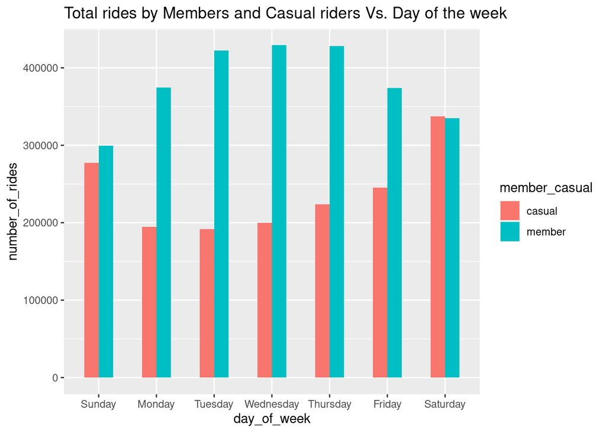

```r
df %>%
  group_by(member_casual, day_of_week) %>%
  summarise(number_of_rides = n(), .groups="drop") %>%
  arrange(member_casual, day_of_week)  %>%
  ggplot(aes(x = day_of_week, y = number_of_rides, fill = member_casual)) +
  labs(title ="Total rides by Members and Casual riders Vs. Day of the week") +
  geom_col(width=0.5, position = position_dodge(width=0.5)) +
  scale_y_continuous(labels = function(x) format(x, scientific = FALSE))
```

From the above graph, we can conclude that members took consistent rides throughout the week with least on Sunday. For the casual riders, the most rides were taken on weekends.

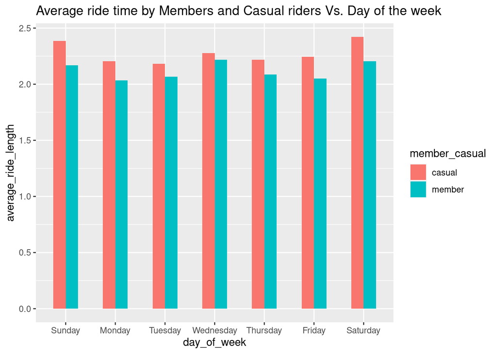

```r
df %>%
  group_by(member_casual, day_of_week) %>%
  summarise(average_ride_length = mean(ride_length), .groups="drop") %>%
  ggplot(aes(x = day_of_week, y = average_ride_length, fill = member_casual)) +
  geom_col(width=0.5, position = position_dodge(width=0.5)) +
  labs(title ="Average ride time by Members and Casual riders Vs. Day of the week")
```

#### **Grouping the rides according to member casual and months of a year**

```r
df %>%
  group_by(member_casual, month) %>%
  summarise(number_of_rides = n(), average_ride_length = mean(ride_length), .groups="drop") %>%
  arrange(member_casual, month)
```

```
## # A tibble: 24 × 4
##    member_casual month    number_of_rides average_ride_length
##    <chr>         <chr>              <int>               <dbl>
##  1 casual        April             102551                2.23
##  2 casual        August            252507                2.33
##  3 casual        December           30197                1.80
##  4 casual        February           30825                1.87
##  5 casual        January            28189                1.73
##  6 casual        July              289054                2.37
##  7 casual        June              269373                2.39
##  8 casual        March              44359                1.89
##  9 casual        May               200562                2.43
## 10 casual        November           69553                2.27
## # ℹ 14 more rows
```